# PML - Course Project

##**Background** **In this project, your goal will be to use data from accelerometers on the belt, forearm, arm, and dumbell of 6 participants. They were asked to perform barbell lifts correctly and incorrectly in 5 different ways. More information is available from the website here: http://groupware.les.inf.puc-rio.br/har (see the section on the Weight Lifting Exercise Dataset).**

##**Submission** **The goal of your project is to predict the manner in which they did the exercise. This is the “classe” variable in the training set. You may use any of the other variables to predict with. You should create a report describing how you built your model, how you used cross validation, what you think the expected out of sample error is, and why you made the choices you did. You will also use your prediction model to predict 20 different test cases.**

###**Getting started**

```r
library(caret)
library(tidyverse)
library(AppliedPredictiveModeling)

#Read file
training <- read.csv("pml-training.csv", header=TRUE)
View(training)
#str(training)
#head(training)

#remove metadata columns
training <- training[,8:160]
View(training)

#final data for predictions
predicting <- read.csv("pml-testing.csv", header=TRUE)
#remove metadata columns
predicting <- predicting[,8:160]


#Step 1: Create partition
#Set seed
set.seed(1234)

training$classe <- (as.factor(training$classe))
training <- data.frame(training)
dim(training)
```

```
## [1] 19622   153
```

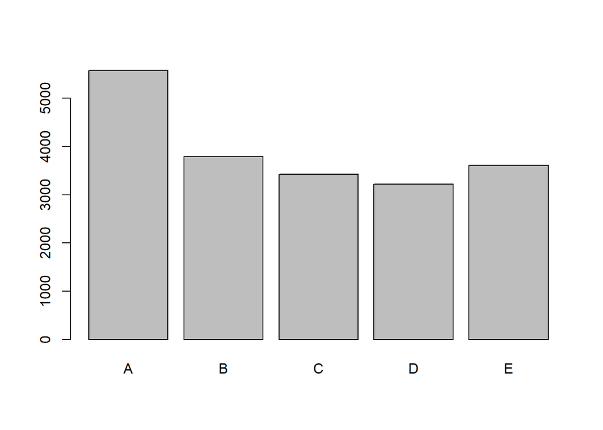

```r
plot(training$classe)
```

```r
#Removing columns of NAs
#First make blank spots NA
training[training == ""] <- NA
View(training)

#any is NA down col (100 gone)
trainingC <- training[, !apply(training, 2, function(x) any(is.na(x)))]
dim(trainingC)
```

```
## [1] 19622    53
```

```r
#View(trainingC)
#proceed with removal of columns with NA

inTrain = createDataPartition(trainingC$classe, p = 3/4)[[1]]
View(inTrain)
length(inTrain)
```

```
## [1] 14718
```

```r
train = trainingC[inTrain,]
View(train)

test = trainingC[-inTrain,]
```

**Cross-validation:** Here we are using a 75%/25% data-split between training/testing datasets for corss-validation purposes. This will allow us to test out-of-sample error on data not used to create the model; this is the accuracy of the predictions.

###**Preprocessing**

```r
#Step 2 - Data exploration and dimension reduction

#Explored 1) preprocess - center, scale, remove near-zero variance or 2) PCA to reduce dimensionality

#Decided to proceed with PCA as pre-process

procTrain2 <- preProcess(train[, -53],
                        method = c("pca"))
procTrain2
```

```
## Created from 14718 samples and 52 variables
##
## Pre-processing:
##   - centered (52)
##   - ignored (0)
##   - principal component signal extraction (52)
##   - scaled (52)
##
## PCA needed 24 components to capture 95 percent of the variance
```

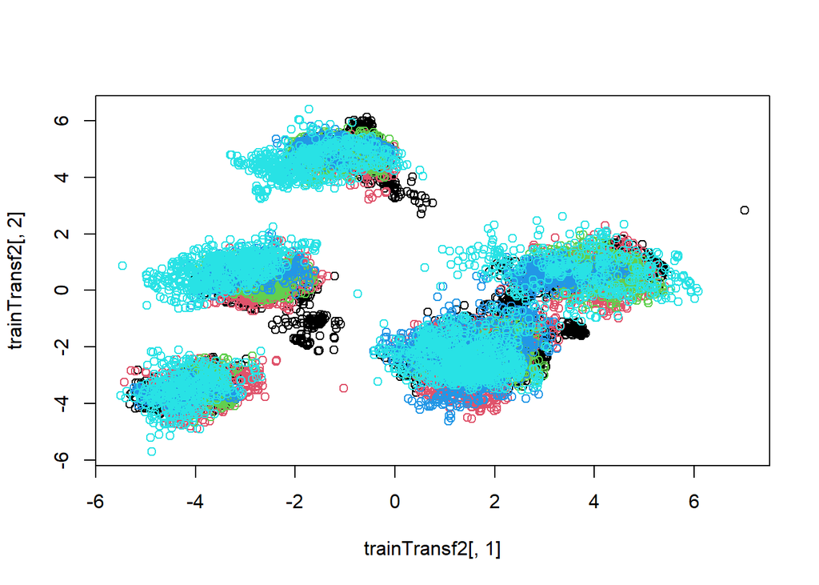

```r
trainTransf2 <- predict(procTrain2, train[, -53])
View(trainTransf2)

plot(trainTransf2[,1],trainTransf2[,2], col=train$classe)
```

```r
#Conclude: Include PCA as preprocess in models below
```

###**Testing Models**

```r
#Step3 - Test models

#rf
library(randomForest)
mdl1 <- randomForest(classe ~ ., method="rf", preProcess = "pca", prox=T, data = train)
mdl1
```

```
##
## Call:
##  randomForest(formula = classe ~ ., data = train, method = "rf",      preProcess = "pca", prox = T)
##                Type of random forest: classification
##                      Number of trees: 500
## No. of variables tried at each split: 7
##
##         OOB estimate of  error rate: 0.48%
## Confusion matrix:
##      A    B    C    D    E  class.error
## A 4183    0    0    1    1 0.0004778973
## B   13 2833    2    0    0 0.0052668539
## C    0   17 2545    5    0 0.0085703155
## D    0    0   22 2388    2 0.0099502488
## E    0    0    0    7 2699 0.0025868441
```

```r
newP1 <- predict(mdl1, test)
#summary(newP1)
confusionMatrix(newP1, test$classe)
```

```
## Confusion Matrix and Statistics
##
##           Reference
## Prediction    A    B    C    D    E
##          A 1395    4    0    0    0
##          B    0  944   10    0    0
##          C    0    1  845    6    0
##          D    0    0    0  798    0
##          E    0    0    0    0  901
##
## Overall Statistics
##
##                Accuracy : 0.9957
##                  95% CI : (0.9935, 0.9973)
##     No Information Rate : 0.2845
##     P-Value [Acc > NIR] : < 2.2e-16
##
##                   Kappa : 0.9946
##
##  Mcnemar's Test P-Value : NA
##
## Statistics by Class:
##
##                      Class: A Class: B Class: C Class: D Class: E
## Sensitivity            1.0000   0.9947   0.9883   0.9925   1.0000
## Specificity            0.9989   0.9975   0.9983   1.0000   1.0000
## Pos Pred Value         0.9971   0.9895   0.9918   1.0000   1.0000
## Neg Pred Value         1.0000   0.9987   0.9975   0.9985   1.0000
## Prevalence             0.2845   0.1935   0.1743   0.1639   0.1837
## Detection Rate         0.2845   0.1925   0.1723   0.1627   0.1837
## Detection Prevalence   0.2853   0.1945   0.1737   0.1627   0.1837
## Balanced Accuracy      0.9994   0.9961   0.9933   0.9963   1.0000
```

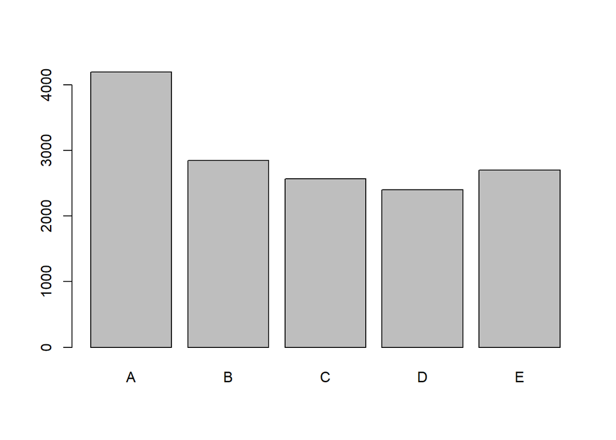

```r
#plot(mdl1)
plot(mdl1$predicted)
```

```r
#gbm
mdl2 <- train(classe ~ ., method="gbm", preProcess = "pca", verbose = F, data = train)
#names(mdl2)
mdl2
```

```
## Stochastic Gradient Boosting
##
## 14718 samples
##    52 predictor
##     5 classes: 'A', 'B', 'C', 'D', 'E'
##
## Pre-processing: principal component signal extraction (52), centered
##  (52), scaled (52)
## Resampling: Bootstrapped (25 reps)
## Summary of sample sizes: 14718, 14718, 14718, 14718, 14718, 14718, ...
## Resampling results across tuning parameters:
##
##   interaction.depth  n.trees  Accuracy   Kappa
##   1                   50      0.5519656  0.4242513
##   1                  100      0.6095079  0.5020026
##   1                  150      0.6393821  0.5412517
##   2                   50      0.6541023  0.5597247
##   2                  100      0.7185826  0.6429266
##   2                  150      0.7538051  0.6879735
##   3                   50      0.7071259  0.6280830
##   3                  100      0.7703489  0.7089476
##   3                  150      0.8061571  0.7544787
##
## Tuning parameter 'shrinkage' was held constant at a value of 0.1
##
## Tuning parameter 'n.minobsinnode' was held constant at a value of 10
## Accuracy was used to select the optimal model using the largest value.
## The final values used for the model were n.trees = 150, interaction.depth =
##  3, shrinkage = 0.1 and n.minobsinnode = 10.
```

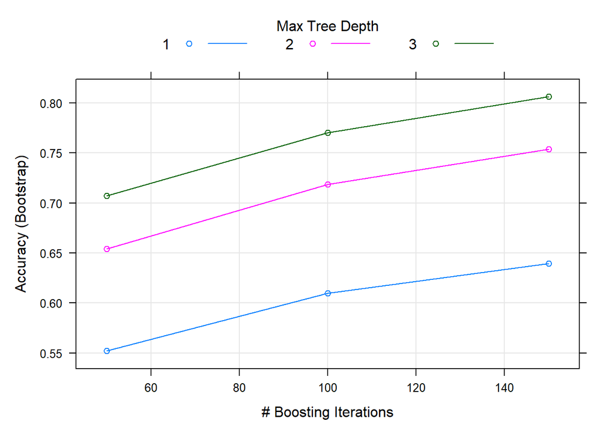

```r
plot(mdl2)
```

```r
newP2 <- predict(mdl2, test)
#summary(newP2)
confusionMatrix(newP2, test$classe)
```

```
## Confusion Matrix and Statistics
##
##           Reference
## Prediction    A    B    C    D    E
##          A 1254  104   24   31   22
##          B   32  732   85   23   77
##          C   51   77  709   87   78
##          D   51    8   24  649   37
##          E    7   28   13   14  687
##
## Overall Statistics
##
##                Accuracy : 0.822
##                  95% CI : (0.811, 0.8326)
##     No Information Rate : 0.2845
##     P-Value [Acc > NIR] : < 2.2e-16
##
##                   Kappa : 0.7746
##
##  Mcnemar's Test P-Value : < 2.2e-16
##
## Statistics by Class:
##
##                      Class: A Class: B Class: C Class: D Class: E
## Sensitivity            0.8989   0.7713   0.8292   0.8072   0.7625
## Specificity            0.9484   0.9451   0.9276   0.9707   0.9845
## Pos Pred Value         0.8739   0.7713   0.7076   0.8440   0.9172
## Neg Pred Value         0.9594   0.9451   0.9626   0.9625   0.9485
## Prevalence             0.2845   0.1935   0.1743   0.1639   0.1837
## Detection Rate         0.2557   0.1493   0.1446   0.1323   0.1401
## Detection Prevalence   0.2926   0.1935   0.2043   0.1568   0.1527
## Balanced Accuracy      0.9237   0.8582   0.8784   0.8890   0.8735
```

```r
#lda
mdl3 <- train(classe ~ ., method="lda", preProcess = "pca", data = train)
#mdl3$finalModel
mdl3
```

```
## Linear Discriminant Analysis
##
## 14718 samples
##    52 predictor
##     5 classes: 'A', 'B', 'C', 'D', 'E'
##
## Pre-processing: principal component signal extraction (52), centered
##  (52), scaled (52)
## Resampling: Bootstrapped (25 reps)
## Summary of sample sizes: 14718, 14718, 14718, 14718, 14718, 14718, ...
## Resampling results:
##
##   Accuracy   Kappa
##   0.5224314  0.3949546
```

```r
newP3 <- predict(mdl3, test)
#summary(newP3)
confusionMatrix(newP3, test$classe)
```

```
## Confusion Matrix and Statistics
##
##           Reference
## Prediction   A   B   C   D   E
##          A 913 212 214  61 114
##          B 149 409  86 150 156
##          C 146 160 449 134 123
##          D 171 105  75 376 112
##          E  16  63  31  83 396
##
## Overall Statistics
##
##                Accuracy : 0.5186
##                  95% CI : (0.5045, 0.5326)
##     No Information Rate : 0.2845
##     P-Value [Acc > NIR] : < 2.2e-16
##
##                   Kappa : 0.3895
##
##  Mcnemar's Test P-Value : < 2.2e-16
##
## Statistics by Class:
##
##                      Class: A Class: B Class: C Class: D Class: E
## Sensitivity            0.6545   0.4310  0.52515  0.46766  0.43951
## Specificity            0.8287   0.8632  0.86095  0.88707  0.95179
## Pos Pred Value         0.6030   0.4305  0.44368  0.44815  0.67233
## Neg Pred Value         0.8578   0.8634  0.89568  0.89471  0.88297
## Prevalence             0.2845   0.1935  0.17435  0.16395  0.18373
## Detection Rate         0.1862   0.0834  0.09156  0.07667  0.08075
## Detection Prevalence   0.3087   0.1937  0.20636  0.17108  0.12011
## Balanced Accuracy      0.7416   0.6471  0.69305  0.67737  0.69565
```

```r
#Select RF due to highest accuracy
```

**Out-of-sample error:** The model that had the highest accuracy and thus lowest out-of-sample error (1-accuracy) on the testing dataset was chosen as the final model.

**The final model selected was a random forest model, which had >99% accuracy in predictions**

###**Final Prediction**

```r
#Step 5 - predictions
final <- predict(mdl1, predicting)
final
```

```
##  1  2  3  4  5  6  7  8  9 10 11 12 13 14 15 16 17 18 19 20
##  B  A  B  A  A  E  D  B  A  A  B  C  B  A  E  E  A  B  B  B
## Levels: A B C D E
```

```r
summary(final)
```

```
## A B C D E
## 7 8 1 1 3
```